# Praca domowa 2

Anna Mazur

## Dane

Dane wykorzystane w Pracy domowej 2 są związane z kampaniami marketingu bezpośredniego portugalskiej instytucji bankowej. Kampanie marketingowe opierały się na rozmowach telefonicznych. Często wymagany był więcej niż jeden kontakt z tym samym klientem, aby uzyskać dostęp do tego, czy produkt (lokata bankowa) zostanie (lub nie) subskrybowany. Opis wszystkich kolumn znajduje się również w pliku `README.md`.

#### Dane klienta banku

| Zmienna | Opis |
| --- | --- |
| **age** | wiek |
| **job** : admin., unknown, unemployed, management, housemaid, entrepreneur, student, blue-collar, self-employed, retired, technician, services | administrator, nieznany, bezrobotny, kierownictwo, pokojówka, przedsiębiorca, student, pracownik fizyczny, samozatrudniony, emeryt, technik, usługi |
| **marital** : married, divorced, single; note: divorced means divorced or widowed) | żonaty/zamężna, rozwiedzion_, kawaler/panna; uwaga: rozwiedzion_ oznacza rozwiedzion_ lub owdowiał_ |
| **education** : unknown, secondary, primary, tertiary | nieznane, średnie, podstawowe, wyższe |
| **default** : yes, no | czy kredyt jest niespłacany : tak, nie |
| **balance** : average yearly balance, in euros | średnie roczne saldo w euro |
| **housing** : has housing loan? yes, no | czy posiada kredyt mieszkaniowy? tak, nie |
| **loan** : has personal loan? yes, no | ma pożyczkę osobistą? tak, nie |

#### Dane związane z ostatnim kontaktem w bieżącej kampanii

| Zmienna | Opis |
| --- | --- |
| **contact** : unknown, telephone, cellular | nieznany, telefon, komórkowy |
| **day** : last contact day of the month | dzień miesiąca ostatniego kontaktu |
| **month** : last contact month of year, jan, feb, mar, …, nov, dec | miesiąc ostatniego kontaktu w roku, styczeń, luty, marzec, …, listopad, grudzień |
| **duration** : last contact duration, in seconds | czas trwania ostatniego kontaktu w sekundach |

## Zadanie 1

Weźmy pod uwagę zawody (`job`) klientów banku. Który zawód zacząco wyróżnia się w posiadaniu kredytu mieszkaniowego lub pożyczki osobistej?

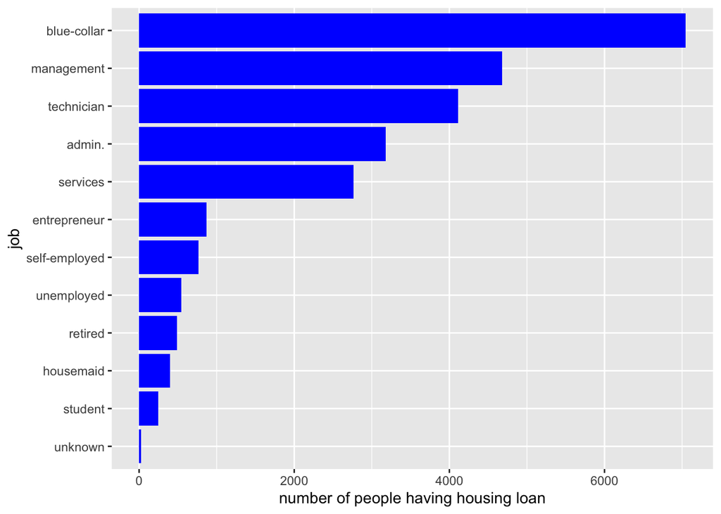

```r
# Tu umieść kod do wygenerowania odpowiedzi do zadania.
zad1 <- df %>%
  group_by(job) %>%
  summarise(
    n_housing = sum(housing == "yes"),
    n_loan = sum(loan == "yes")
  )

zad1 %>%
  ggplot(aes(y = forcats::fct_reorder(job, n_housing), x = n_housing))+
  geom_col(fill = "blue")+
  labs(
    y = "job",
    x = "number of people having housing loan",
  )
```

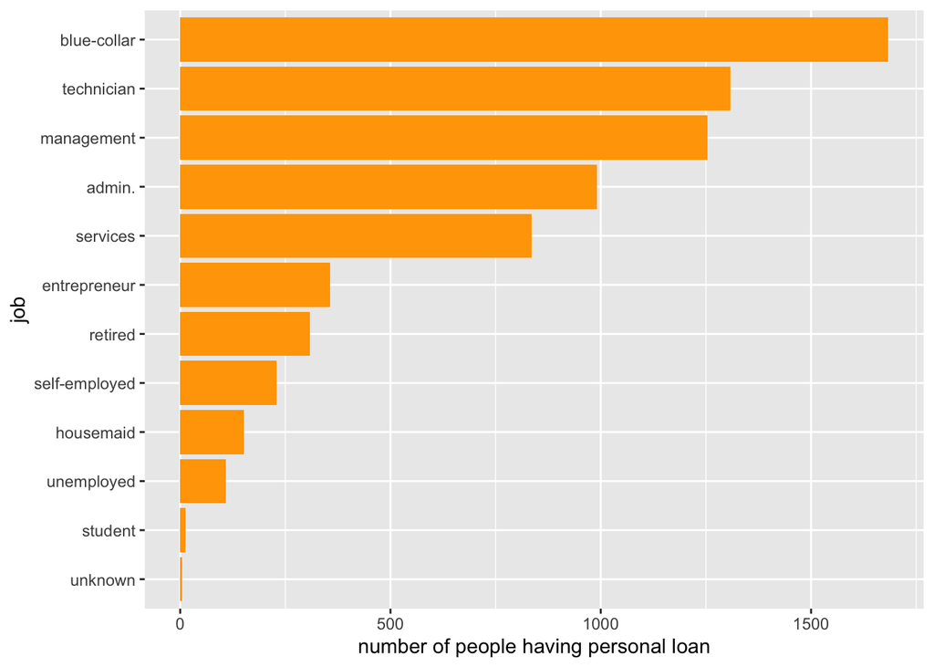

```r
zad1 %>%
  ggplot(aes(y = forcats::fct_reorder(job, n_loan), x = n_loan))+
  geom_col(fill = "orange")+
  labs(
    y = "job",
    x = "number of people having personal loan",
  )
```

**Komentarz:** Najwięcej pożyczek (kredytów mieszkaniowych i kredytów osobistych) biorą pracownicy fizyczni.

## Zadanie 2

Wybierając klientów, którzy mają nieznany sposób kontaktu (`contact`). Jak rozkłada się ich wiek w podziale na status związku?

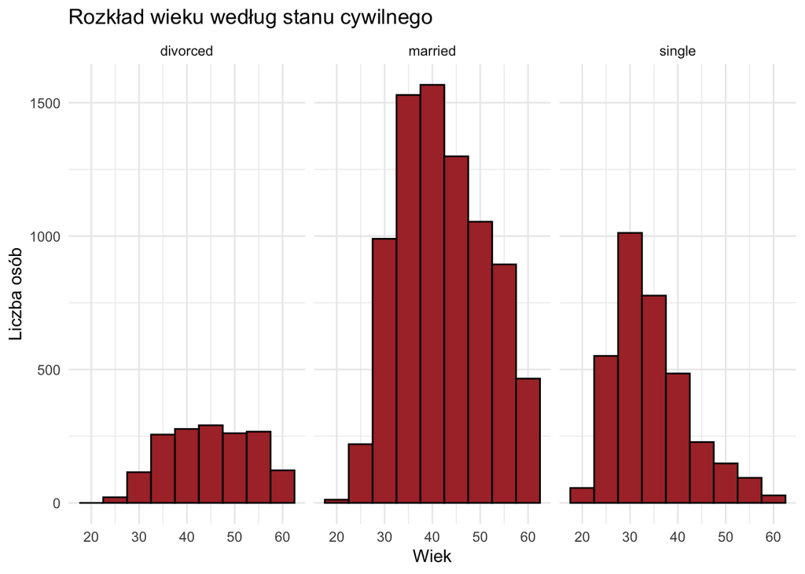

```r
# Tu umieść kod do wygenerowania odpowiedzi do zadania.

df %>%
  filter(contact == "unknown") %>%
  ggplot(aes(x = age)) +
  geom_histogram(binwidth = 5, color = "black", fill = "#ab3333") +
  facet_wrap(~ marital) +
  labs(
    x = "Wiek",
    y = "Liczba osób",
    title = "Rozkład wieku według stanu cywilnego"
  ) +
  theme_minimal()
```

**Komentarz:** Wśród rozwiedzionych wiek rozkłada się dość równomiernie (oprócz kategorii wiekowych 20-35 i 55-60). Liczby te są stosunkowo niewielkie (ok. 250 osób w danej kategorii wiekowej). Najwięcej osób po ślubie ma 35-45 lat. Zamężna czy żonaty to również najczęściej pojawiający się stan cywilny (z trzech rozważanych) we wszystkich grupach oprócz osób w wieku 20-35, gdzie dominuje bycie singlem. Między 30 a 35 rokiem życia odnotowuje się najwięcej singli, a między 60 a 65 – najmniej.

## Zadanie 3

Jaka jest różnica pomiędzy średnim rocznym saldem w euro w zależności od wykształcenia i tego czy kredyt jest niespłacany?

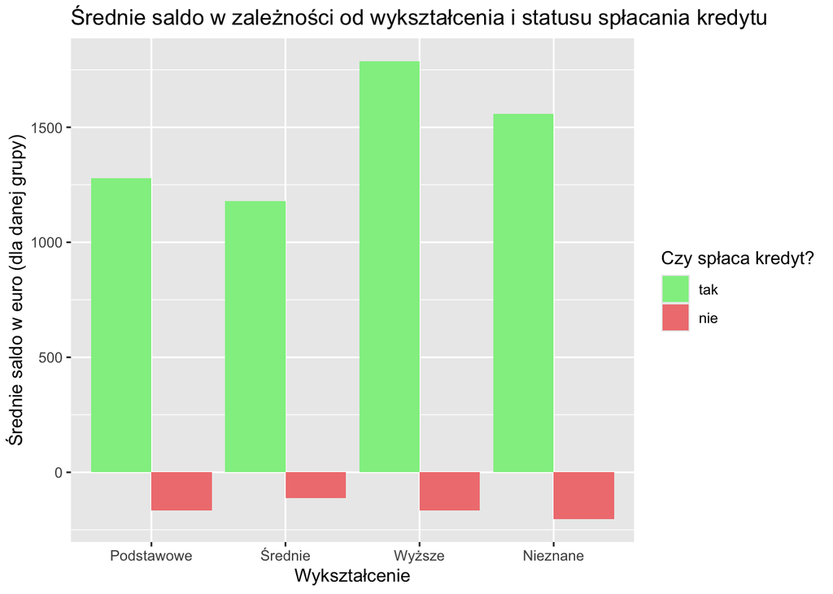

```r
# Tu umieść kod do wygenerowania odpowiedzi do zadania.
df %>%
  group_by(education, default) %>%
  summarise(mean_balance = mean(balance)) %>%
  ggplot(aes(x = education, y = mean_balance, fill = default)) +
  geom_bar(stat = "identity", position = "dodge") +
  scale_fill_manual(
    values = c("yes" = "lightcoral", "no" = "lightgreen"),
    labels = c("yes" = "nie", "no" = "tak")
    )+
  labs(
    x = "Wykształcenie",
    y = "Średnie saldo w euro (dla danej grupy)",
    title = "Średnie saldo w zależności od wykształcenia i statusu spłacania kredytu",
    fill = "Czy spłaca kredyt?"
    )+
  scale_x_discrete(labels = c(
    "primary" = "Podstawowe",
    "secondary" = "Średnie",
    "tertiary" = "Wyższe",
    "unknown" = "Nieznane")
    )
```

**Komentarz:** Obserwujemy następującą zależność: osoby, których średnie roczne saldo jest dodatnie, spłacają kredyt, natomiast saldo osób, które kredytu nie spłacają, jest ujemne.

## Zadanie 4

Czy dzień i miesiąc kontaktu z klientem ma wpływ na średni czas trwania rozmowy w stosunku do średniego czasu trwania rozmowy?

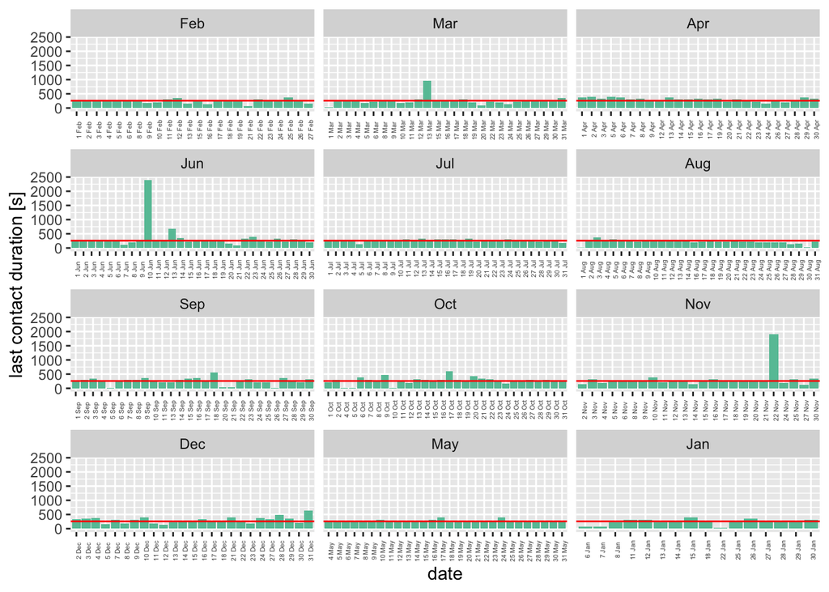

```r
# Tu umieść kod do wygenerowania odpowiedzi do zadania.
mean_duration_general <- mean(df$duration, na.rm = TRUE)

df %>%
  group_by(day, month) %>%
  summarise(mean_duration_daily = mean(duration)) %>%
  mutate(
    month = str_to_title(month),
    month = fct_reorder(month, match(month, str_to_title(month.abb))),
    date = factor(paste(day, month), levels = paste(rep(1:31, each = 12), rep(str_to_title(month.abb), times = 31)))
  ) %>%
  arrange(month, day) %>%
  ggplot(aes(x = date, y = mean_duration_daily))+
  geom_col(fill = "#66c2a5")+
  geom_hline(yintercept = mean_duration_general, linetype = "solid", color = "red")+
  facet_wrap(~month, scales = "free_x", ncol = 3) +
  theme(axis.text.x = element_text(angle = 90, size = 4))+
  labs(
    y = "last contact duration [s]"
  )
```

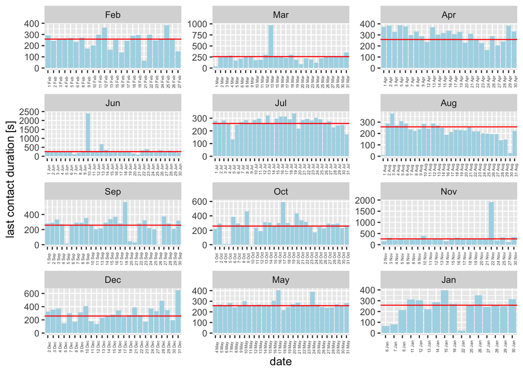

```r
df %>%
  group_by(day, month) %>%
  summarise(mean_duration_daily = mean(duration)) %>%
  mutate(
    month = str_to_title(month),
    month = fct_reorder(month, match(month, str_to_title(month.abb))),
    date = factor(paste(day, month), levels = paste(rep(1:31, each = 12), rep(str_to_title(month.abb), times = 31)))
  ) %>%
  arrange(month, day) %>%
  ggplot(aes(x = date, y = mean_duration_daily))+
  geom_col(fill = "lightblue")+
  geom_hline(yintercept = mean_duration_general, linetype = "solid", color = "red")+
  facet_wrap(~month, scales = "free", ncol = 3) +
  theme(axis.text.x = element_text(angle = 90, size = 4))+
  labs(
    y = "last contact duration [s]"
  )
```

## Zadanie 5

Czy jest zależność pomiędzy wiekiem klientów a ich średnim rocznym saldzie w euro w podziale na stopień wykształcenia?

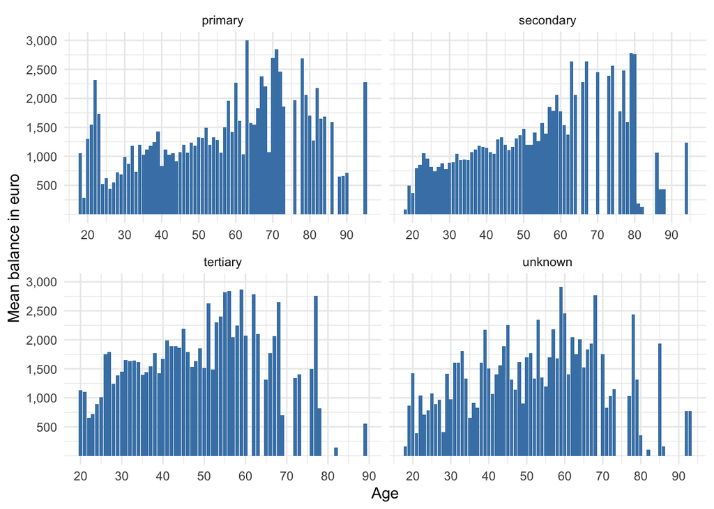

```r
# Tu umieść kod do wygenerowania odpowiedzi do zadania.
df %>%
  group_by(age, education) %>%
  summarise(mean_by_age = mean(balance, na.rm = TRUE), .groups = "drop") %>%
  ggplot(aes(x = age, y = mean_by_age)) +
  geom_col(fill = "steelblue") +
  facet_wrap(~education, scales = "free_x") +
  scale_x_continuous(breaks = seq(20, max(df$age, na.rm = TRUE), by = 10)) +
  scale_y_continuous(labels = scales::comma, limits = c(0, 3000), breaks = seq(500, 3000, 500)) +
  labs(
    y = "Mean balance in euro",
    x = "Age"
  ) +
  theme_minimal()
```

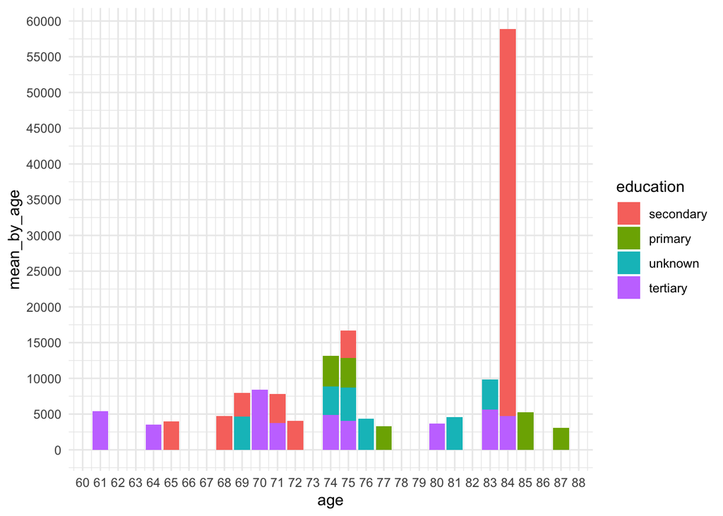

```r
df %>%
  group_by(age, education) %>%
  summarise(mean_by_age = mean(balance, na.rm = TRUE), .groups = "drop") %>%
  filter(mean_by_age > 3000) %>%
  mutate(education = fct_reorder(education, mean_by_age)) %>%
  ggplot(aes(x = age, y = mean_by_age, fill = education))+
  geom_col(position = "stack")+
  scale_x_continuous(breaks = seq(min(df$age), max(df$age), by = 1)) +
  scale_y_continuous(breaks = seq(0, 60000, 5000))+
  theme_minimal()
```

**Komentarz:** W przypadku gdy wykształcenie jest znane, generalna tendencja jest taka, że im człowiek starszy, tym ma wyższe roczne saldo. W przeciwnym przypadku trudno zauważyć jakąś zależność. Na drugim wykresie zamieściłam te obserwacje, które przekraczały 3000. Z nich można odczytać informacje o najbogatszych jednostkach dla każdej grupy.

## Zadanie 6

Rozważmy osoby, które są bezrobotne albo ich zawód jest nieznany. Czy procent osób, które są bezrobotne i nie spłacają kredytu jest większy od procenta osób o nieznanym zawodzie i niespłacanym kredycie? Jaki typ kredytu jest (przez te osoby) najczęściej niespłacany?

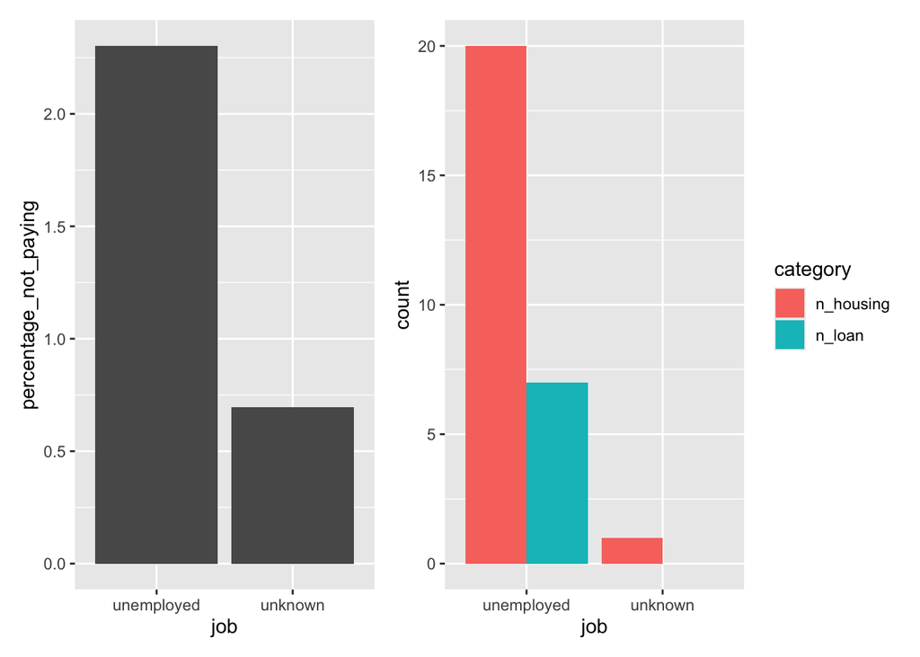

```r
# Tu umieść kod do wygenerowania odpowiedzi do zadania.


plot1 <- df %>%
  filter(job == "unknown" | job == "unemployed") %>%
  group_by(job) %>%
  summarise(
    total = n(),
    not_paying_credit = sum(default == "yes"),
    percentage_not_paying = (not_paying_credit / total) * 100
  ) %>%
  ggplot(aes(x = job, y = percentage_not_paying))+
  geom_col()

plot2 <- df %>%
  filter(default == "yes") %>%
  filter(job == "unemployed" | job == "unknown") %>%
  group_by(job) %>%
  summarise(
    n_housing = sum(housing == "yes"),
    n_loan = sum(loan == "yes")
  ) %>%
  pivot_longer(cols = c(n_loan, n_housing), names_to = "category", values_to = "count") %>%
  ggplot(aes(x = job, y = count, fill = category)) +
  geom_col(position = "dodge")


plot1 + plot2
```

**Komentarz:** Około 2,3 % bezrobotnych nie płaci kredytu, natomiast dla osób o nieznanym statusie zatrudnienia ten odsetek wynosi ok. 0,7%. W obu przypadkach najczęściej niespłacany jest kredyt mieszkaniowy.